# Color Schemes in Data Visualization

Cheng Peng

West Chester University

# 1 Introduction

Data visualization becomes more effective when the colors are chosen carefully. It is convenient to have convenient color schemes ready for different type of data that are

- distinct for all people, including color-blind readers;
- distinct from black and white;
- distinct on screen and paper;
- matching well together.

This note discusses briefly such color schemes. A color scheme should reflect each of the three types of data:

**Qualitative data** - nominal or categorical data, where magnitude differences are not relevant. This includes lines in plots and text in presentations.

**Diverging data** - data ordered between two extremes where the midpoint is important, e.g. positive and negative deviations from zero or a mean.

**Sequential data** - data ordered from low to high.

# 2 Qualitative Color Schemes

There are several color blind safe color schemes for qualitative data. The following are short list of these suggested default schemes for further modifications. Qualitative color schemes are probably most important and used in data visualization.

- **Bright Scheme**

Bright qualitative color scheme that is color-blind safe. The main scheme for lines and their labels.

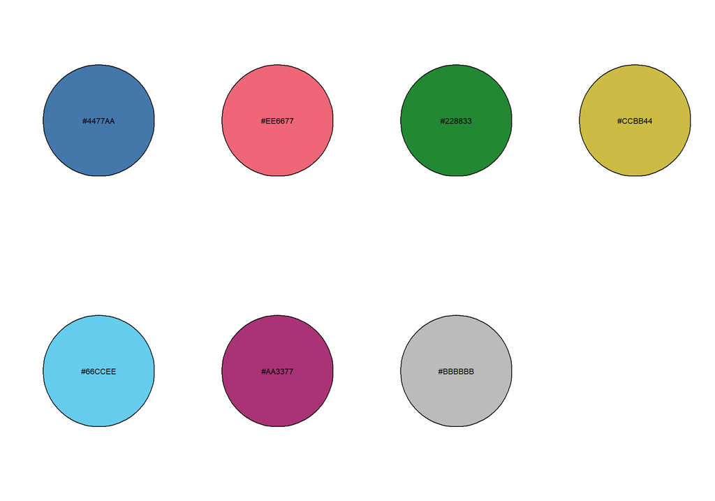

```r
par(mfrow=c(2,4))
plot(1:5,type="n", axes = FALSE, xlab = "", ylab = "")
draw.circle(3,3,2,col="#4477AA")
text(3,3, "#4477AA")
##
plot(1:5,type="n", axes = FALSE, xlab = "", ylab = "")
draw.circle(3,3,2,col="#EE6677")
text(3,3, "#EE6677")
##
plot(1:5,type="n", axes = FALSE, xlab = "", ylab = "")
draw.circle(3,3,2,col="#228833")
text(3,3, "#228833")
##
plot(1:5,type="n",axes = FALSE, xlab = "", ylab = "")
draw.circle(3,3,2,col="#CCBB44")
text(3,3, "#CCBB44")
##
plot(1:5,type="n", axes = FALSE, xlab = "", ylab = "")
draw.circle(3,3,2,col="#66CCEE")
text(3,3, "#66CCEE")
##
plot(1:5,type="n", axes = FALSE, xlab = "", ylab = "")
draw.circle(3,3,2,col="#AA3377")
text(3,3, "#AA3377")
##
plot(1:5,type="n", axes = FALSE, xlab = "", ylab = "")
draw.circle(3,3,2,col="#BBBBBB")
text(3,3, "#BBBBBB")
```

- **High-contrast Scheme**

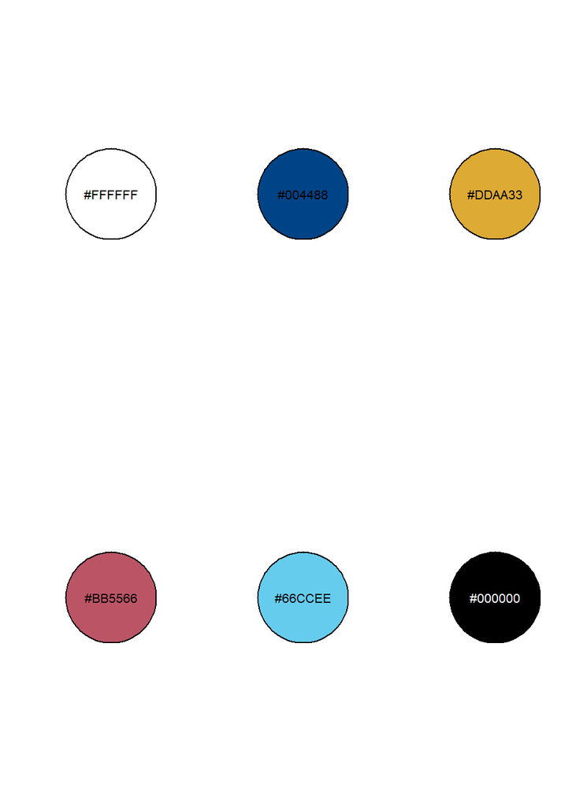

```r
par(mfrow=c(2,3))
plot(1:5,type="n", axes = FALSE, xlab = "", ylab = "", cex = 0.8)
draw.circle(3,3,2,col="#FFFFFF")
text(3,3, "#FFFFFF")
##
plot(1:5,type="n", axes = FALSE, xlab = "", ylab = "")
draw.circle(3,3,2,col="#004488")
text(3,3, "#004488")
##
plot(1:5,type="n", axes = FALSE, xlab = "", ylab = "")
draw.circle(3,3,2,col="#DDAA33")
text(3,3, "#DDAA33")
##
plot(1:5,type="n",axes = FALSE, xlab = "", ylab = "")
draw.circle(3,3,2,col="#BB5566")
text(3,3, "#BB5566")
##
plot(1:5,type="n", axes = FALSE, xlab = "", ylab = "")
draw.circle(3,3,2,col="#66CCEE")
text(3,3, "#66CCEE")
##
plot(1:5,type="n", axes = FALSE, xlab = "", ylab = "")
draw.circle(3,3,2,col="#000000")
text(3,3, "#000000", col = "#FFFFFF")
```

- **Vibrant Scheme**

Vibrant qualitative color scheme, an alternative to the bright scheme that is equally color-blind safe. It has been designed for data visualization framework.

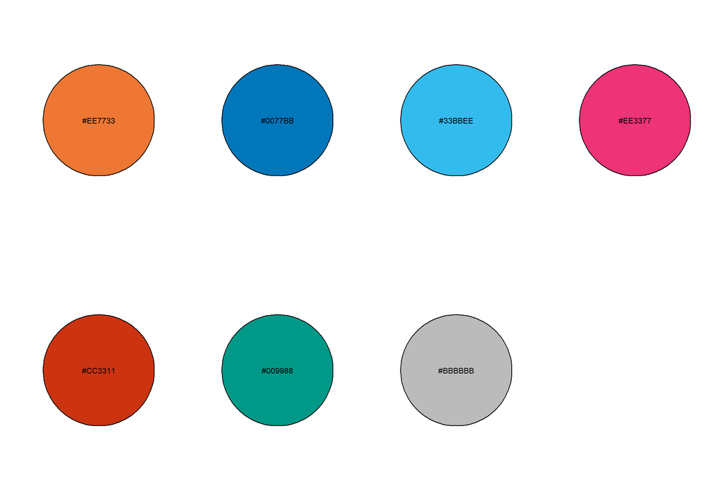

```r
par(mfrow=c(2,4))
plot(1:5,type="n", axes = FALSE, xlab = "", ylab = "")
draw.circle(3,3,2,col="#EE7733")
text(3,3, "#EE7733")
##
plot(1:5,type="n", axes = FALSE, xlab = "", ylab = "")
draw.circle(3,3,2,col="#0077BB")
text(3,3, "#0077BB")
##
plot(1:5,type="n", axes = FALSE, xlab = "", ylab = "")
draw.circle(3,3,2,col="#33BBEE")
text(3,3, "#33BBEE")
##
plot(1:5,type="n",axes = FALSE, xlab = "", ylab = "")
draw.circle(3,3,2,col="#EE3377")
text(3,3, "#EE3377")
##
plot(1:5,type="n", axes = FALSE, xlab = "", ylab = "")
draw.circle(3,3,2,col="#CC3311")
text(3,3, "#CC3311")
##
plot(1:5,type="n", axes = FALSE, xlab = "", ylab = "")
draw.circle(3,3,2,col="#009988")
text(3,3, "#009988")
##
plot(1:5,type="n", axes = FALSE, xlab = "", ylab = "")
draw.circle(3,3,2,col="#BBBBBB")
text(3,3, "#BBBBBB")
```

- **Muted Scheme**

Muted qualitative color scheme, an alternative to the bright scheme that is equally color-blind safe with more colours, but lacking a clear red or medium blue.

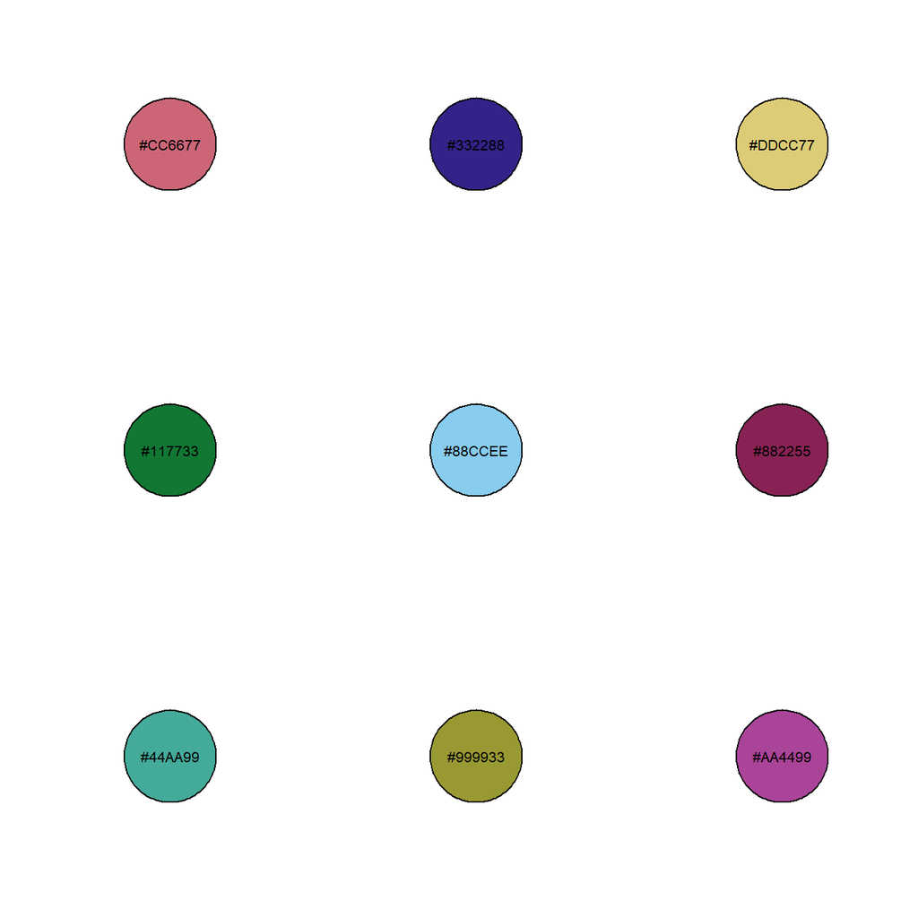

```r
par(mfrow=c(3,3))

plot(1:5,type="n", axes = FALSE, xlab = "", ylab = "")
draw.circle(3,3,1,col="#CC6677")
text(3,3, "#CC6677")
##
plot(1:5,type="n", axes = FALSE, xlab = "", ylab = "")
draw.circle(3,3,1,col="#332288")
text(3,3, "#332288")
##
plot(1:5,type="n", axes = FALSE, xlab = "", ylab = "")
draw.circle(3,3,1,col="#DDCC77")
text(3,3, "#DDCC77")
##
plot(1:5,type="n",axes = FALSE, xlab = "", ylab = "")
draw.circle(3,3,1,col="#117733")
text(3,3, "#117733")
##
plot(1:5,type="n", axes = FALSE, xlab = "", ylab = "")
draw.circle(3,3,1,col="#88CCEE")
text(3,3, "#88CCEE")
##
plot(1:5,type="n", axes = FALSE, xlab = "", ylab = "")
draw.circle(3,3,1,col="#882255")
text(3,3, "#882255")
##
plot(1:5,type="n",axes = FALSE, xlab = "", ylab = "")
draw.circle(3,3,1,col="#44AA99")
text(3,3, "#44AA99")
##
plot(1:5,type="n", axes = FALSE, xlab = "", ylab = "")
draw.circle(3,3,1,col="#999933")
text(3,3, "#999933")
##
plot(1:5,type="n", axes = FALSE, xlab = "", ylab = "")
draw.circle(3,3,1,col="#AA4499")
text(3,3, "#AA4499")
```

- **Medium-contrast Scheme**

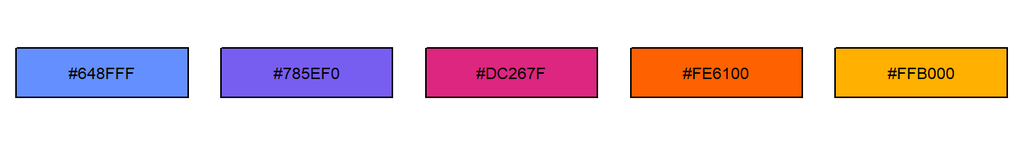

```r
par(mfrow=c(1,5), oma=c(0,0,0,0), mar = c(1,0.5,1,0.5))
plot(NULL, type="n", xlim=c(-1,1), ylim=c(-1,1), axes = FALSE, xlab = "", ylab = "")
rect(xleft = -1, ybottom = -0.5, xright =1, ytop = 0.5, lty = 1, col = "#648FFF")
text(0,0, "#648FFF")
##
plot(NULL, type="n", xlim=c(-1,1), ylim=c(-1,1), axes = FALSE, xlab = "", ylab = "")
rect(xleft = -1, ybottom = -0.5, xright =1, ytop = 0.5, lty = 1, col = "#785EF0")
text(0,0, "#785EF0")
##
plot(NULL, type="n", xlim=c(-1,1), ylim=c(-1,1), axes = FALSE, xlab = "", ylab = "")
rect(xleft = -1, ybottom = -0.5, xright =1, ytop = 0.5, lty = 1, col = "#DC267F")
text(0,0, "#DC267F")
##
plot(NULL, type="n", xlim=c(-1,1), ylim=c(-1,1), axes = FALSE, xlab = "", ylab = "")
rect(xleft = -1, ybottom = -0.5, xright =1, ytop = 0.5, lty = 1, col = "#FE6100")
text(0,0, "#FE6100")
##
plot(NULL, type="n", xlim=c(-1,1), ylim=c(-1,1), axes = FALSE, xlab = "", ylab = "")
rect(xleft = -1, ybottom = -0.5, xright =1, ytop = 0.5, lty = 1, col = "#FFB000")
text(0,0, "#FFB000")
```

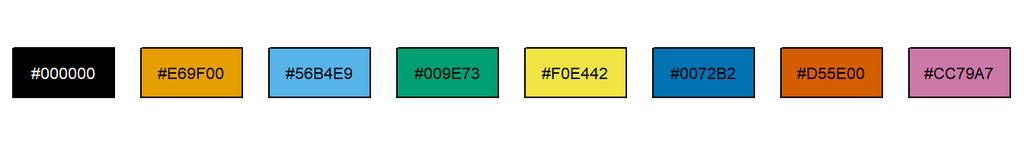

```r
par(mfrow=c(1,8), oma=c(0,0,0,0), mar = c(1,0.5,1,0.5))
plot(NULL, type="n", xlim=c(-1,1), ylim=c(-1,1), axes = FALSE, xlab = "", ylab = "")
rect(xleft = -1, ybottom = -0.5, xright =1, ytop = 0.5, lty = 1, col = "#000000")
text(0,0, "#000000", col = "white")
##
plot(NULL, type="n", xlim=c(-1,1), ylim=c(-1,1), axes = FALSE, xlab = "", ylab = "")
rect(xleft = -1, ybottom = -0.5, xright =1, ytop = 0.5, lty = 1, col = "#E69F00")
text(0,0, "#E69F00")
##
plot(NULL, type="n", xlim=c(-1,1), ylim=c(-1,1), axes = FALSE, xlab = "", ylab = "")
rect(xleft = -1, ybottom = -0.5, xright =1, ytop = 0.5, lty = 1, col = "#56B4E9")
text(0,0, "#56B4E9")
##
plot(NULL, type="n", xlim=c(-1,1), ylim=c(-1,1), axes = FALSE, xlab = "", ylab = "")
rect(xleft = -1, ybottom = -0.5, xright =1, ytop = 0.5, lty = 1, col = "#009E73")
text(0,0, "#009E73")
##
plot(NULL, type="n", xlim=c(-1,1), ylim=c(-1,1), axes = FALSE, xlab = "", ylab = "")
rect(xleft = -1, ybottom = -0.5, xright =1, ytop = 0.5, lty = 1, col = "#F0E442")
text(0,0, "#F0E442")
##
plot(NULL, type="n", xlim=c(-1,1), ylim=c(-1,1), axes = FALSE, xlab = "", ylab = "")
rect(xleft = -1, ybottom = -0.5, xright =1, ytop = 0.5, lty = 1, col = "#0072B2")
text(0,0, "#0072B2")
##
plot(NULL, type="n", xlim=c(-1,1), ylim=c(-1,1), axes = FALSE, xlab = "", ylab = "")
rect(xleft = -1, ybottom = -0.5, xright =1, ytop = 0.5, lty = 1, col = "#D55E00")
text(0,0, "#D55E00")
##
plot(NULL, type="n", xlim=c(-1,1), ylim=c(-1,1), axes = FALSE, xlab = "", ylab = "")
rect(xleft = -1, ybottom = -0.5, xright =1, ytop = 0.5, lty = 1, col = "#CC79A7")
text(0,0, "#CC79A7")
```

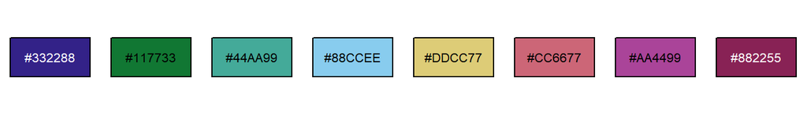

```r
par(mfrow=c(1,8), oma=c(0,0,0,0), mar = c(1,0.5,1,0.5))

plot(NULL, type="n", xlim=c(-1,1), ylim=c(-1,1), axes = FALSE, xlab = "", ylab = "")
rect(xleft = -1, ybottom = -0.5, xright =1, ytop = 0.5, lty = 1, col = "#332288")
text(0,0, "#332288", col = "white")
##
plot(NULL, type="n", xlim=c(-1,1), ylim=c(-1,1), axes = FALSE, xlab = "", ylab = "")
rect(xleft = -1, ybottom = -0.5, xright =1, ytop = 0.5, lty = 1, col = "#117733")
text(0,0, "#117733")
##
plot(NULL, type="n", xlim=c(-1,1), ylim=c(-1,1), axes = FALSE, xlab = "", ylab = "")
rect(xleft = -1, ybottom = -0.5, xright =1, ytop = 0.5, lty = 1, col = "#44AA99")
text(0,0, "#44AA99")
##
plot(NULL, type="n", xlim=c(-1,1), ylim=c(-1,1), axes = FALSE, xlab = "", ylab = "")
rect(xleft = -1, ybottom = -0.5, xright =1, ytop = 0.5, lty = 1, col = "#88CCEE")
text(0,0, "#88CCEE")
##
plot(NULL, type="n", xlim=c(-1,1), ylim=c(-1,1), axes = FALSE, xlab = "", ylab = "")
rect(xleft = -1, ybottom = -0.5, xright =1, ytop = 0.5, lty = 1, col = "#DDCC77")
text(0,0, "#DDCC77")
##
plot(NULL, type="n", xlim=c(-1,1), ylim=c(-1,1), axes = FALSE, xlab = "", ylab = "")
rect(xleft = -1, ybottom = -0.5, xright =1, ytop = 0.5, lty = 1, col = "#CC6677")
text(0,0, "#CC6677")
##
plot(NULL, type="n", xlim=c(-1,1), ylim=c(-1,1), axes = FALSE, xlab = "", ylab = "")
rect(xleft = -1, ybottom = -0.5, xright =1, ytop = 0.5, lty = 1, col = "#AA4499")
text(0,0, "#AA4499")
##
plot(NULL, type="n", xlim=c(-1,1), ylim=c(-1,1), axes = FALSE, xlab = "", ylab = "")
rect(xleft = -1, ybottom = -0.5, xright =1, ytop = 0.5, lty = 1, col = "#882255")
text(0,0, "#882255", col = "white")
```

**Example**: Iris Data

The following the ggplot code generates the density curves of sepal length and width across the three species of iris flowers based on the well known iris data set.

[output not shown]

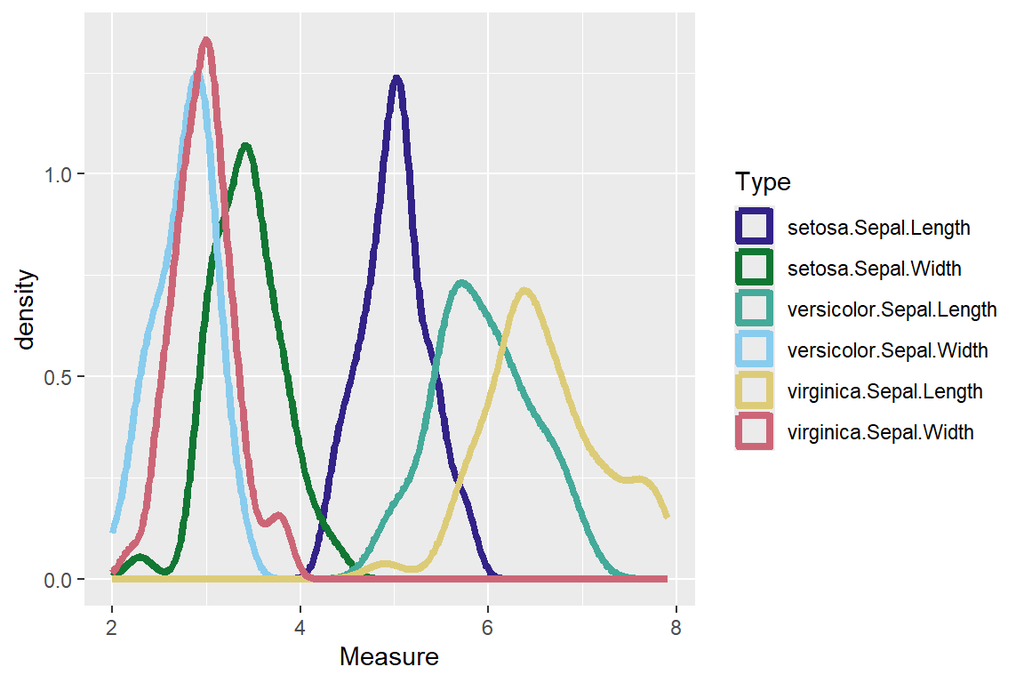

```r
iris0 = iris
Type = c(paste(iris$Species,".Sepal.Length", sep = ""),paste(iris$Species,".Sepal.Width", sep = ""))
Measure = c(iris$Sepal.Length ,iris$Sepal.Width)
irisNew = data.frame(Type = Type, Measure = Measure)
cols1 = c("#332288","#117733","#44AA99","#88CCEE","#DDCC77","#CC6677")
cols3 = c("#AA4499","#882255")
ggplot() +
      geom_density(data = irisNew, aes(x = Measure, color = Type), lwd = 1.5)+
      scale_color_manual(values = cols1)
```

# 3 Divergence and Sequential Colors

We only give simple examples to show the two types of color schemes.

**Sequential Colors**

For ordered numeric data (low to high values)

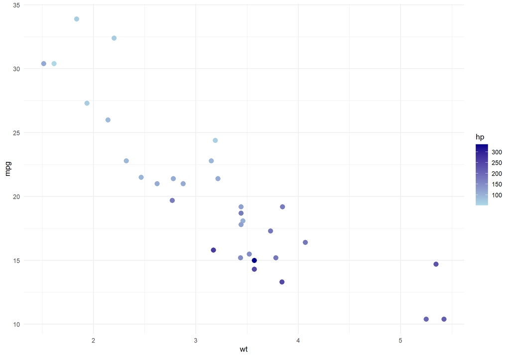

```r
#library(ggplot2)

# Built-in sequential palettes
ggplot(mtcars, aes(wt, mpg, color = hp)) +
  geom_point(size = 3) +
  scale_color_gradient(low = "lightblue", high = "darkblue") +
  theme_minimal()
```

**Diverging Colors**

For data with a meaningful midpoint (e.g., deviations, correlations)

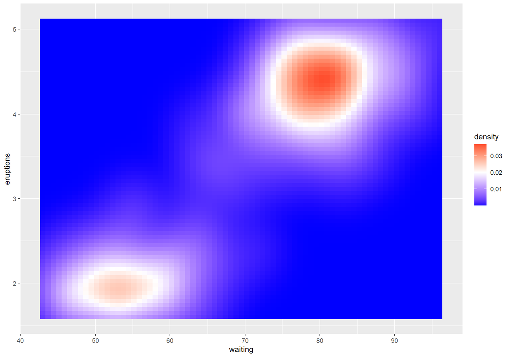

```r
# Diverging palette example
ggplot(faithfuld, aes(waiting, eruptions, fill = density)) +
  geom_tile() +
  scale_fill_gradient2(
    low = "blue",
    mid = "white",
    high = "red",
    midpoint = 0.02
  )
```

# 4 Popular Color Palette Packages

**RColorBrewer (built-in)**

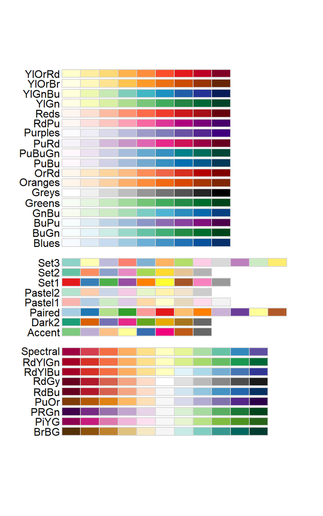

```r
# Display all palettes
library(RColorBrewer)
display.brewer.all()
```

We can also use command `display.brewer.all(colorblindFriendly = TRUE)` to display only color blind friendly color palettes.

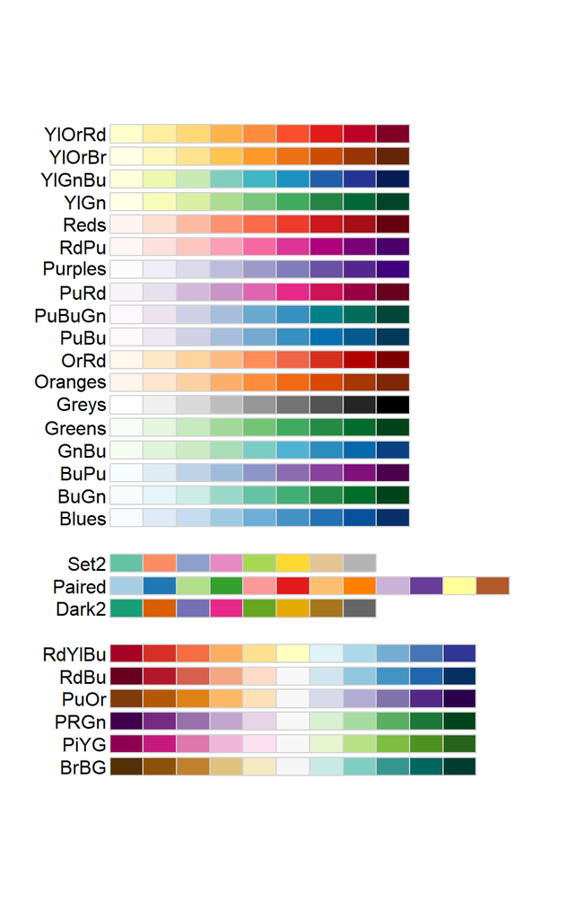

```r
display.brewer.all(colorblindFriendly = TRUE)
```

* **Not color blind friendly palette**

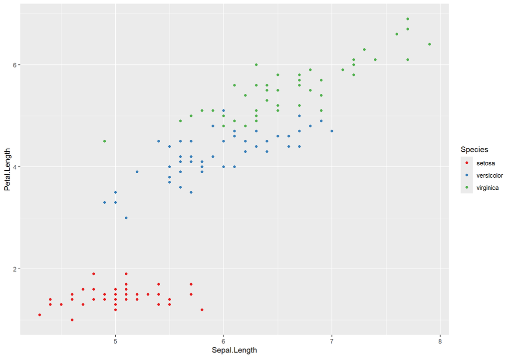

```r
# Usage examples
ggplot(iris, aes(Sepal.Length, Petal.Length, color = Species)) +
  geom_point() +
  scale_color_brewer(palette = "Set1")  # Qualitative
```

- **Color blind friendly palette**

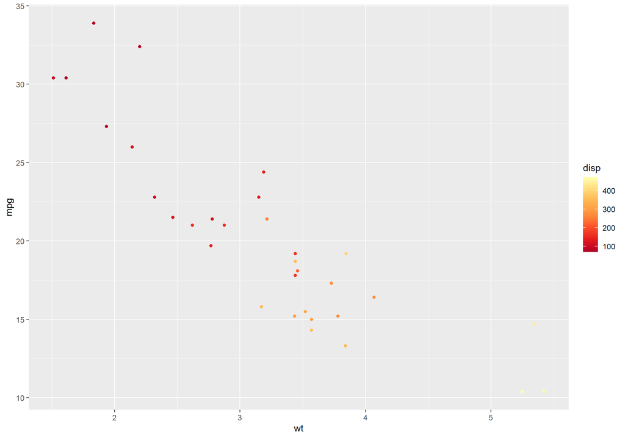

```r
ggplot(mtcars, aes(wt, mpg, color = disp)) +
  geom_point() +
  scale_color_distiller(palette = "YlOrRd")  # Sequential
```

**viridis** (perceptually uniform, colorblind-friendly)

- *For continuous data*

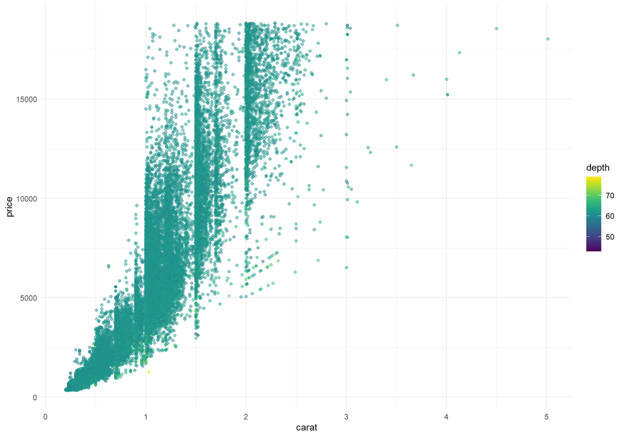

```r
library(viridis)
# For discrete data
ggplot(diamonds, aes(carat, price, color = depth)) +
  geom_point(alpha = 0.5) +
  scale_color_viridis(option = "D") +  # Options: A, B, C, D, E
  theme_minimal()
```

- *For discrete data*

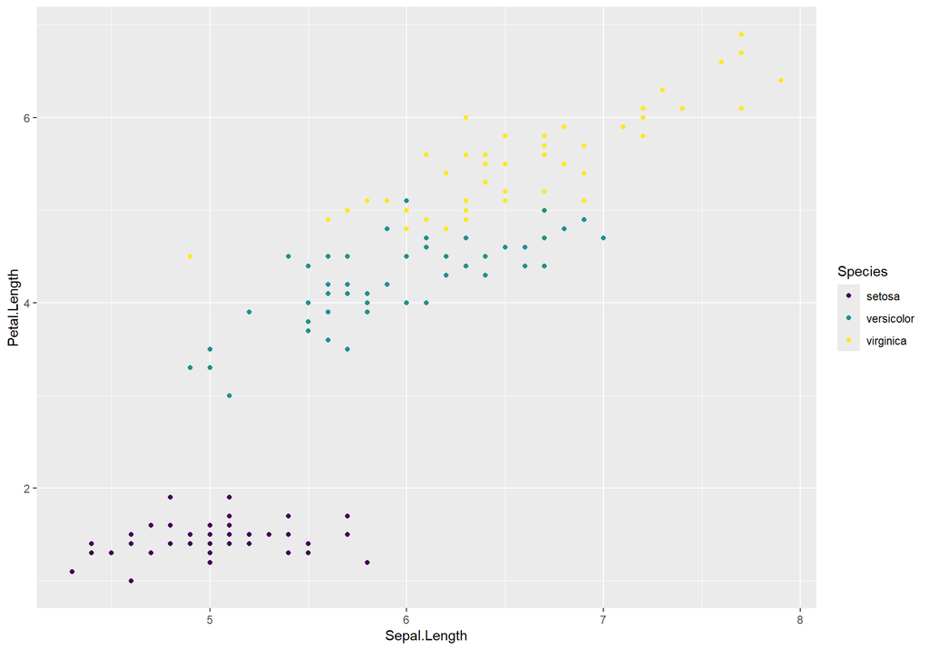

```r
# For discrete data
ggplot(iris, aes(Sepal.Length, Petal.Length, color = Species)) +
  geom_point() +
  scale_color_viridis_d()
```

**Other specialized palettes**

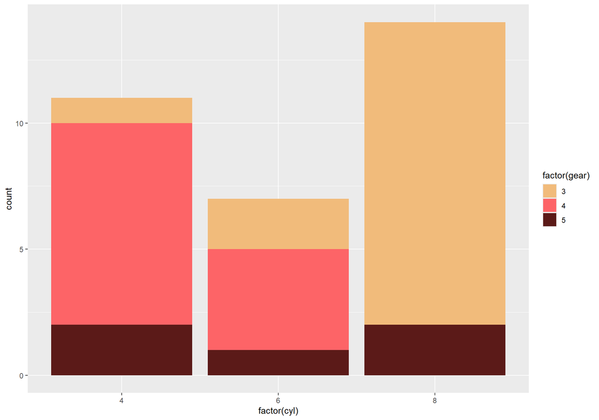

```r
# Wes Anderson palettes
library(wesanderson)
ggplot(mtcars, aes(factor(cyl), fill = factor(gear))) +
  geom_bar() +
  scale_fill_manual(values = wes_palette("GrandBudapest1"))
```

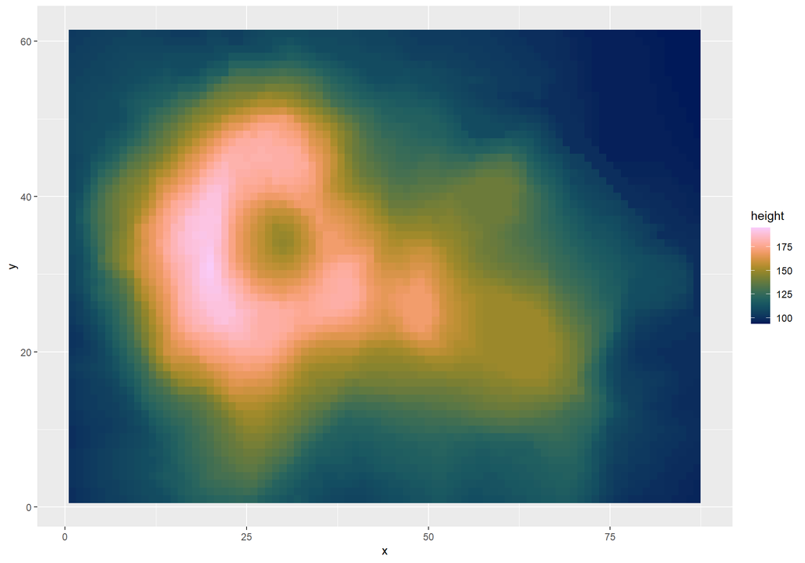

```r
# Scientific palettes
library(scico)
# Convert the volcano matrix to a data frame
volcano_df <- expand.grid(
  x = 1:nrow(volcano),
  y = 1:ncol(volcano)
)
volcano_df$height <- as.vector(volcano)
##
ggplot(volcano_df, aes(x, y, fill = height)) +
  geom_tile() +
  scale_fill_scico(palette = "batlow")  # Colorblind-safe
```

# 5 Custom Color Schemes

**Creating custom palettes**

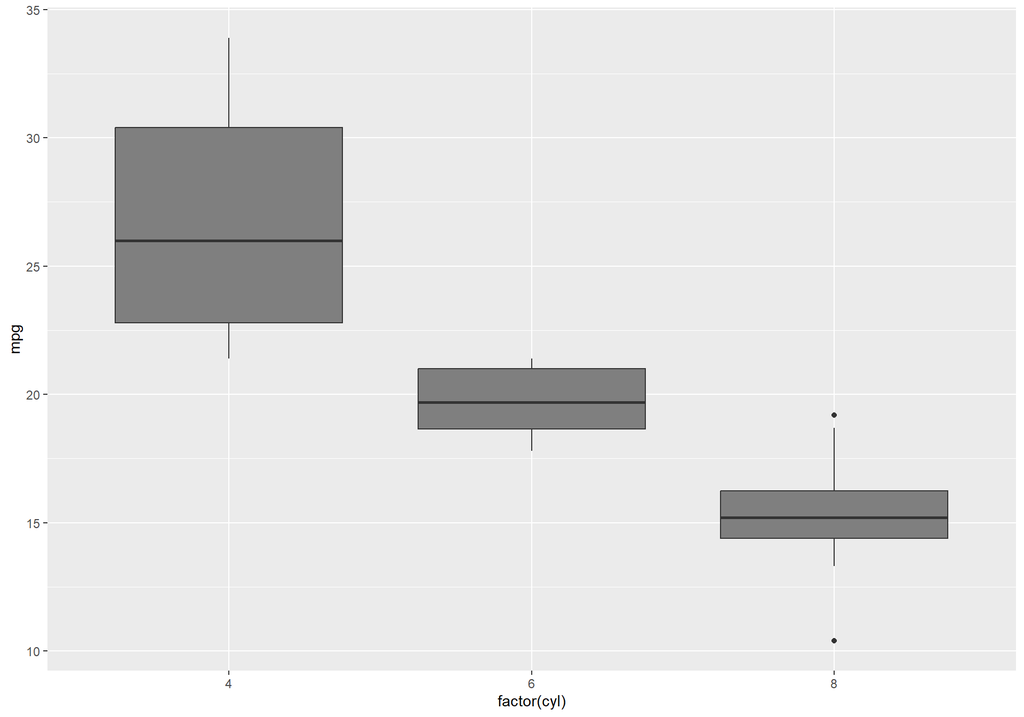

```r
# Define custom colors
my_colors <- c(
  "Category1" = "#2C3E50",
  "Category2" = "#E74C3C",
  "Category3" = "#3498DB",
  "Category4" = "#2ECC71"
)

ggplot(mtcars, aes(factor(cyl), mpg, fill = factor(cyl))) +
  geom_boxplot() +
  scale_fill_manual(values = my_colors)
```

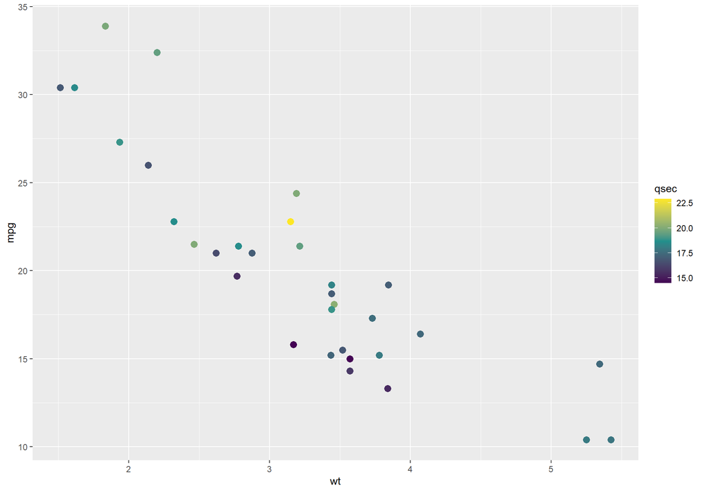

```r
# Custom gradient
ggplot(mtcars, aes(wt, mpg, color = qsec)) +
  geom_point(size = 3) +
  scale_color_gradientn(
    colors = c("#440154", "#21908C", "#FDE725")  # viridis colors
  )
```

**Brand-specific palettes**

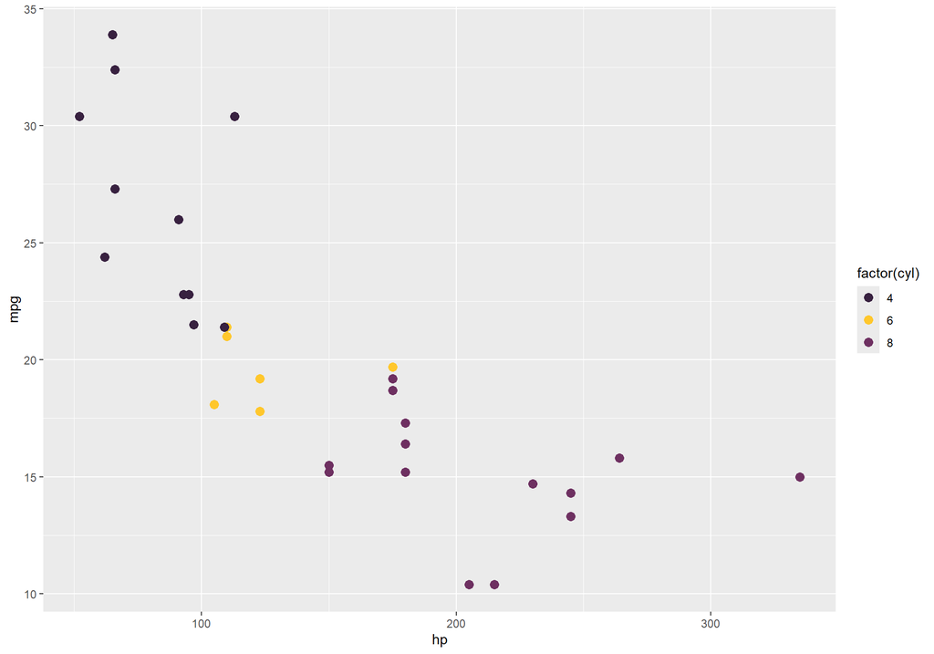

```r
# Corporate color palette
brand_palette <- function(n) {
  colors <- c("#382140", "#ffc72c",  "#6e3061", "#d4a129")
  if (n <= length(colors)) {
    return(colors[1:n])
  } else {
    colorRampPalette(colors)(n)
  }
}

# Use in plot
ggplot(mtcars, aes(hp, mpg, color = factor(cyl))) +
  geom_point(size = 3) +
  scale_color_manual(values = brand_palette(3))
```

# 6 Best Practices and Guidelines for Color Selection

**Accessibility considerations**

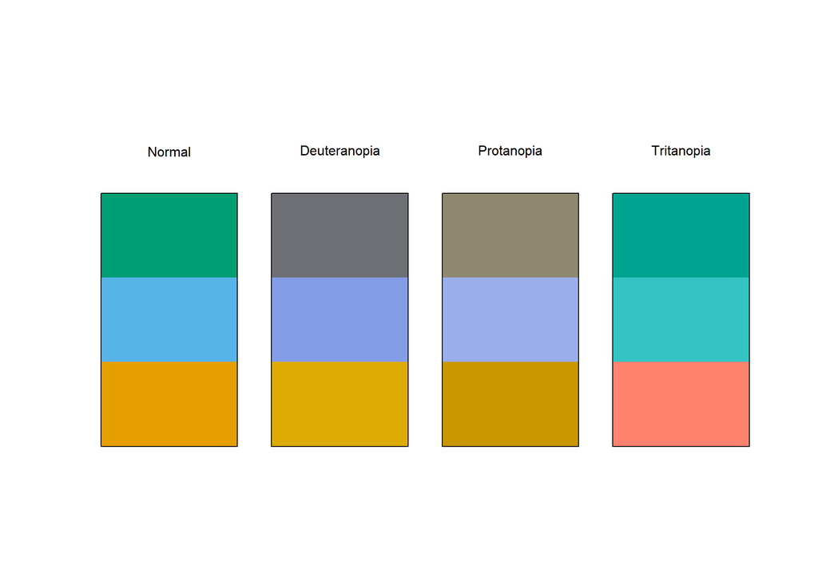

```r
# Test for colorblind accessibility
library(colorblindcheck)
library(prismatic)
palette <- c("#E69F00", "#56B4E9", "#009E73")
check_color_blindness(palette)
```

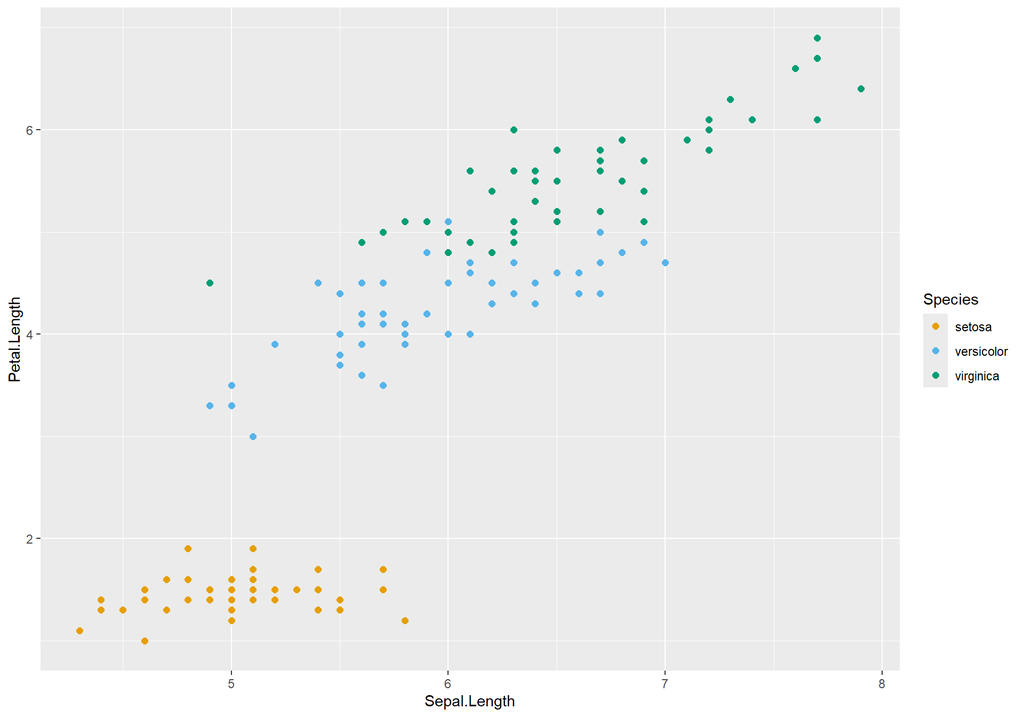

```r
# Colorblind-friendly palette from Wong (2011)
cb_palette <- c(
  "#E69F00",  # Orange
  "#56B4E9",  # Sky Blue
  "#009E73",  # Green
  "#F0E442",  # Yellow
  "#0072B2",  # Blue
  "#D55E00",  # Vermillion
  "#CC79A7"   # Pink
)

ggplot(iris, aes(Sepal.Length, Petal.Length, color = Species)) +
  geom_point(size = 2) +
  scale_color_manual(values = cb_palette)
```

**Context-appropriate choices**

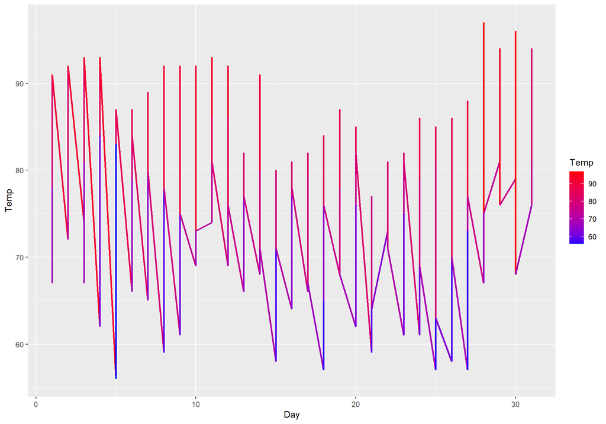

```r
# Temperature data → warm/cool intuitive mapping
ggplot(airquality, aes(Day, Temp, color = Temp)) +
  geom_line(size = 1) +
  scale_color_gradient(low = "blue", high = "red")
```

```r
# Survey responses (agree/disagree) → diverging
survey_colors <- scale_fill_gradient2(
  low = "#ca0020",   # Strongly disagree (red)
  mid = "#f7f7f7",   # Neutral (white)
  high = "#0571b0",  # Strongly agree (blue)
  midpoint = 3
)
```

**Number of colors guideline**

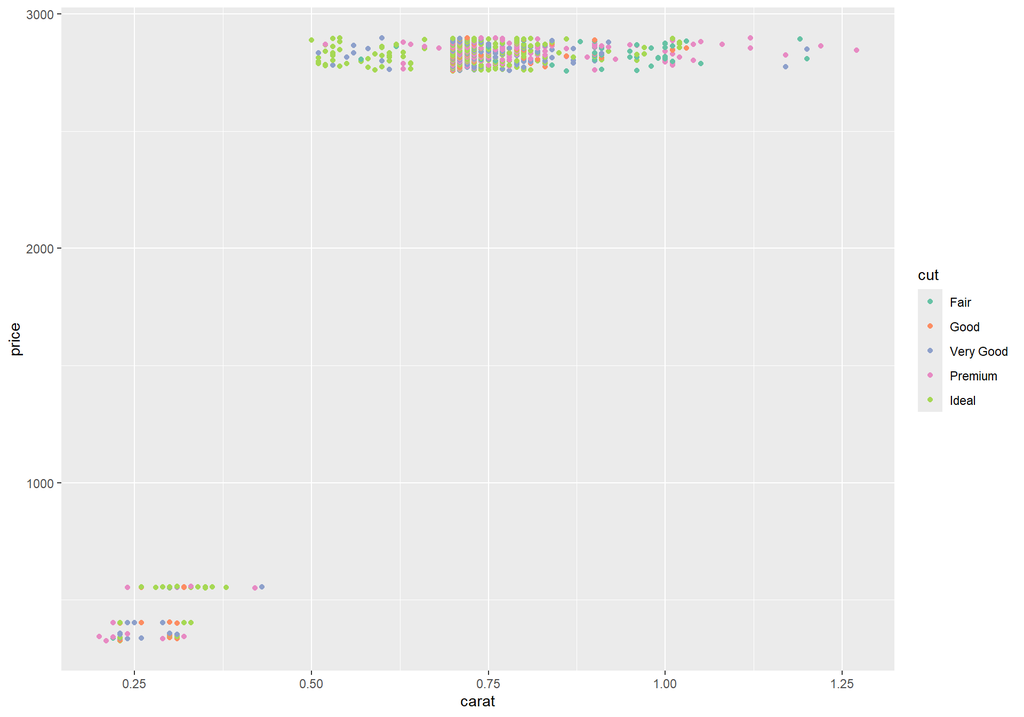

```r
# Good: Limited palette (≤ 6-8 colors)
ggplot(diamonds[1:1000,], aes(carat, price, color = cut)) +
  geom_point() +
  scale_color_brewer(palette = "Set2")  # 5 colors max
```

**Bad**: Too many colors become indistinguishable. Avoid using more than 8 distinct colors if possible

**Contrast and emphasis**

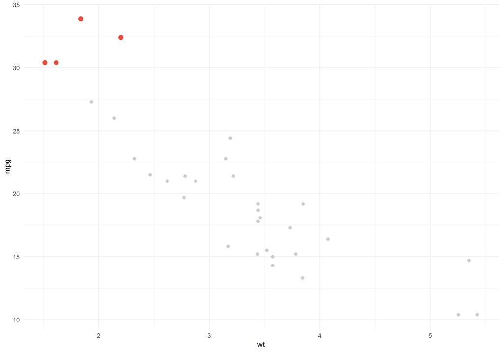

```r
# Use color to highlight key data points
ggplot(mtcars, aes(wt, mpg)) +
  geom_point(color = "grey80", size = 2) +  # Background points
  geom_point(
    data = mtcars[mtcars$mpg > 30,],
    color = "#E74C3C",
    size = 3
  ) +  # Highlight efficient cars
  theme_minimal()
```

# 7 Color Scheme Selection Guide

| Data Type | Scheme Type | Example Packages |
| --- | --- | --- |
| Continuous (one direction) | Sequential | `viridis`, `RColorBrewer` |
| Continuous (two directions) | Diverging | `RColorBrewer`, `scico` |
| Categorical (≤8 groups) | Qualitative | `RColorBrewer`, `wesanderson` |
| Categorical (>8 groups) | Use shapes/text | — |
| Accessibility priority | Perceptually uniform | `viridis`, `cividis` |

**Quick Decision Helper**

```r
# Function to recommend color scheme
recommend_scheme <- function(data_type, n_categories = NULL) {
  if (data_type == "sequential") {
    return("Use scale_color_viridis_c() or scale_color_gradient()")
  } else if (data_type == "diverging") {
    return("Use scale_color_gradient2() with appropriate midpoint")
  } else if (data_type == "categorical") {
    if (n_categories <= 8) {
      return("Use scale_color_brewer(palette = 'Set2')")
    } else {
      return("Consider using facets or shapes instead of color")
    }
  }
}
# Example call
recommend_scheme("categorical", n_categories = 5)
```

```
## [1] "Use scale_color_brewer(palette = 'Set2')"
```